# PROGRAMACION LINEAL EN R

Irma Noemí No

1/9/2021

# Hola!!!

## Orientación básica

Para ejecutar los códigos aquí expuestos y crear nuevos, puedes indistintamente:

1. Utilizar tu entorno [RStudio](https://www.rstudio.com/), si lo tienes descargado en tu PC
2. Trabajar en [RCloud](https://rstudio.cloud/) (recuerda crear un usuario)
3. Utilizar [Google Colaboratory](https://colab.research.google.com) ([Video](https://www.youtube.com/watch?v=VmEA6nioero) de ayuda para utilizar código R allí).

   Entre otras posibilidades ([Jupyter](https://jupyter.org/) Notebooks, etc.).

## Función `simplex()` del package `boot`

Sirve para problemas de tamaño no muy grande (leer Nota en la ayuda).

Instalar y cargar package previamente. [[Fuente](http://www3.uji.es/~gregori/docencia/mt1021-1617/mt1021-1617-la-5-proglin.html)]

**Función****:** `simplex(a, A1, b1, A2, b2, A3, b3, maxi, n.iter, eps)`

**Argumentos****:**

- `a`: coeficientes de la función objetivo
- `A1`: matriz de restricciones de tipo ≤ (sólo la parte de coeficientes)
- `b1`: vector de términos independientes de las restricciones de tipo ≤ (correspondientes a la matriz A1)
- `A2`: idem con restricciones de tipo ≥
- `b2:` idem correspondientes a la matriz A2
- `A3`: idem con restricciones de tipo =
- `b3`: idem correspondientes a la matriz A3
- `maxi`: Poner a TRUE si se desea maximizar la función objetivo
- `n.iter`: número máximo de iteraciones en cada fase (usa método de dos fases)
- `eps`: tolerancia de coma flotante

**Devuelve****:** un objeto de la clase simplex, que es una lista con componentes (entre otros):

- `$soln`: solución óptima, si se alcanza
- `$solved`: código de terminación:
  - `1` indica solución óptima encontrada
  - `0` indica que se ha alcanzado el número máximo de iteraciones sin acabar
  - `-1` indica que no existe solución factible
- `$value:` valor de la función objetivo en la solución $soln

etc.

## Ejemplos

[[Fuente](https://cape.fcfm.buap.mx/jdzf/cursos/proba2/libros/grossman.pdf) enunciados]

- Maximice: $z=5x_1+6x_2$ sujeta a:
  $$\begin{eqnarray}
  3x_1 + 2x_2 \leq 120 \\
  4x_1 + 6x_2 \leq 260 \\
  x_1, x_2 \geq 0
  \end{eqnarray}$$

```r
library(boot)
#a coef. función objetivo
a=c(5,6)
#A1 matriz de coef. desigualdades <=
A1=matrix(c(3,2,4,6),2,2,byrow=TRUE)
#b1 términos indep. de desigualdades <=
b1=c(120,260)
simplex1<- simplex(a, A1, b1, maxi=TRUE )
simplex1
```

```
##
## Linear Programming Results
##
## Call : simplex(a = a, A1 = A1, b1 = b1, maxi = TRUE)
##
## Maximization Problem with Objective Function Coefficients
## x1 x2
##  5  6
##
##
## Optimal solution has the following values
## x1 x2
## 20 30
## The optimal value of the objective  function is 280.
```

- Minimice: $z=3x_1+6x_2$ sujeta a:
  $$\begin{eqnarray}
  4x_1 + x_2 \geq 20 \\
  x_1 + x_2 \leq 20 \\
  x_1 + x_2 \geq 10 \\
  x_1, x_2 \geq 0
  \end{eqnarray}$$

```r
library(boot)
#a coef. función objetivo
a=c(3,6)
#A1 matriz de coef. desigualdades <=
A1=matrix(c(1,1),1,2,byrow=TRUE)
#b1 términos indep. de desigualdades <=
b1=20
#A2 matriz de coef. desigualdades >=
A2=matrix(c(4,1,1,1),2,2,byrow=TRUE)
#b2 términos indep. de desigualdades <=
b2=c(20,10)
simplex2<- simplex(a, A1, b1, A2, b2, maxi=FALSE )
simplex2
```

```
##
## Linear Programming Results
##
## Call : simplex(a = a, A1 = A1, b1 = b1, A2 = A2, b2 = b2, maxi = FALSE)
##
## Minimization Problem with Objective Function Coefficients
## x1 x2
##  3  6
##
##
## Optimal solution has the following values
## x1 x2
## 10  0
## The optimal value of the objective  function is 30.
```

- Maximice: $z=3x_1-2x_2+2x_3$ sujeta a:
  $$\begin{eqnarray}
  x_1 + x_2+ x_3 \leq 15 \\
  2x_1 + x_2 +2x_3\leq 26 \\
  5x_1 + 2x_2 +3x_3\leq 43 \\
  x_1, x_2, x_3 \geq 0
  \end{eqnarray}$$

```r
library(boot)
#a coef. función objetivo
a=c(3,-2, 2)
#A1 matriz de coef. desigualdades <=
A1=matrix(c(1,1,1,2,1,2,5,2,3),3,3,byrow=TRUE)
#b1 términos indep. de desigualdades <=
b1=c(15,26,43)
simplex3<- simplex(a, A1, b1, maxi=TRUE )
simplex3
```

```
##
## Linear Programming Results
##
## Call : simplex(a = a, A1 = A1, b1 = b1, maxi = TRUE)
##
## Maximization Problem with Objective Function Coefficients
## x1 x2 x3
##  3 -2  2
##
##
## Optimal solution has the following values
## x1 x2 x3
##  2  0 11
## The optimal value of the objective  function is 28.
```

- Minimice: $z=1.5x_1+x_2+2.5x_3$ sujeta a:
  $$\begin{eqnarray}
  0.5x_1 + 0.6x_2+0.4x_3 \geq 6 \\
  0.2x_1 + 0.1x_2 +0.3x_3\geq 3.1 \\
  x_1, x_2, x_3 \geq 0
  \end{eqnarray}$$

```r
library(boot)
#a coef. función objetivo
a=c(1.5,1,2.5)
A1=0
b1=0
#A2 matriz de coef. desigualdades >=
A2=matrix(c(0.5,0.6,0.4,0.2,0.1,0.3),2,3,byrow=TRUE)
#b2 términos indep. de desigualdades >=
b2=c(6,3.1)
simplex4<- simplex(a, A1, b1, A2, b2, maxi=FALSE )
simplex4
```

```
##
## Linear Programming Results
##
## Call : simplex(a = a, A1 = A1, b1 = b1, A2 = A2, b2 = b2, maxi = FALSE)
##
## Minimization Problem with Objective Function Coefficients
##  x1  x2  x3
## 1.5 1.0 2.5
##
##
## Optimal solution has the following values
##   x1   x2   x3
## 15.5  0.0  0.0
## The optimal value of the objective  function is 23.25.
```

## Función `lp()` del package `lpSolve`

Se trara de otra función para resolver PPLs, pero más completa pues admite variables enteras (programación entera) y variables binarias (programación 0-1).

Para usarla hay que instalar y cargar el package previamente. [[Fuente](http://www3.uji.es/~gregori/docencia/mt1021-1617/mt1021-1617-la-5-proglin.html)]

**Función:** `lp (direction, objective.in, const.mat, const.dir, const.rhs, int.vec, binary.vec)`

**Argumentos:**

- `direction`: poner `'max'` si se quiere maximizar la función objetivo
- `objective.in`: vector con coeficientes de la función objetivo
- `const.mat`: matriz de coeficientes de las restricciones
- `const.dir`: vector de cadenas de texto indicando la dirección de cada restricción (`"<="`, `"=,"` o `">="`)
- `const.rhs`: vector de términos independientes de las restricciones
- `int.vec`: Vector indicando qué variables son enteras
- `binary.vec`: Vector indicando qué variables son 0-1

**Devuelve:** un objeto de la clase `lp`, que es una lista con componentes (entre otras):

- `$objval`: valor de la función objetivo en el óptimo
- `$solution`: solución óptima
- `$status`: indicador numérico:
  - `0`: éxito
  - `2`: no hay solución factible

## Ejemplo

`lpSolve`asume que todas las variables son `no negativas.`

Si queremos tener una variable libre, es necesario hacer la siguiente transformación: `Xn = XnA - XnB`, donde XnA y XnB son no negativas. [[Fuente](https://cran.r-project.org/doc/contrib/Optimizacion_Matematica_con_R_Volumen_I.pdf)]

- Maximice: $z=x_1+9x_2+3x_3$ sujeta a:
  $$\begin{eqnarray}
  x_1 + 2x_2+3x_3 \geq 1 \\
  3x_1 + 2x_2 +2x_3\leq 15 \\
  x_1\in \{0;1\},\hspace{0.3cm} x_2\land x_3 \in \ Z
  \end{eqnarray}$$

```r
library(lpSolve)
objective.in <- c(1, 9, 3)
const.mat <-  matrix (c(1, 2, 3, 3, 2, 2), nrow=2,
                               byrow=TRUE)
const.dir <- c(">=", "<=")
const.rhs <- c(1, 15)
lpmax <- lp ("max", objective.in, const.mat,
            const.dir, const.rhs, compute.sens=TRUE,
            int.vec=c(2:3), binary.vec=c(1))
#ver si hubo éxito y valor hallado:
lpmax
```

```
## Success: the objective function is 63
```

```r
#ver donde se alcanza el óptimo:
lpmax$solution
```

```
## [1] 0 7 0
```

- El mismo problema anterior, sin pedir variables enteras ni binarias:

```r
library(lpSolve)
objective.in <- c(1, 9, 3)
const.mat <-  matrix (c(1, 2, 3, 3, 2, 2), nrow=2,
                               byrow=TRUE)
const.dir <- c(">=", "<=")
const.rhs <- c(1, 15)
lpmax2 <- lp ("max", objective.in, const.mat,
            const.dir, const.rhs, compute.sens=TRUE)
#ver si hubo éxito y valor hallado:
lpmax2
```

```
## Success: the objective function is 67.5
```

```r
#ver donde se alcanza el óptimo:
lpmax2$solution
```

```
## [1] 0.0 7.5 0.0
```

Ahora un ejemplo sin solución (Región disjunta, fuente: Grossman):

  $$\begin{eqnarray}
  2x_1 + 2x_2 \geq 6 \\
  x_1 + x_2 \leq 1 \\
  \end{eqnarray}$$

  ```r
  library(lpSolve)
  problem.coef.obj <- c(3, 6)
  problem.coef.restr <-  matrix (c(2, 2, 1, 1), nrow=2,
                                 byrow=TRUE)
  problem.dir.restr <- c(">=", "<=")
  problem.term.restr <- c(6, 1)
  lpnul <- lp ("max", problem.coef.obj, problem.coef.restr,
              problem.dir.restr, problem.term.restr, compute.sens=TRUE,
              int.vec=c(2:3), binary.vec=c(1))
  #ver si hubo éxito y valor hallado:
  lpnul
  ```

  ```
  ## Error: no feasible solution found
  ```

  ```r
  #ver donde se alcanza el óptimo:
  lpnul$solution
  ```

  ```
  ## [1] 0 0
  ```

## Funcionalidad específica para el transporte:

## Función `lp.transport()` del package `lpSolve`

Debemos construir la Matriz de costo.

En esta matriz cada elemento `[i,j]`nos dice cuál es costo unitario de transporte desde `"i"` a `"j"`.

### Ejemplo:

La empresa “España” dedicada al tratamiento, recuperación y transformación de RAEE dispone de 2 plantas de operación (ubicadas en Madrid y Zaragoza) y 8 almacenes en los cuales se depositan los residuos hasta agotar su capacidad de acopio (situados en Madrid, Zaragoza, Bilbao, Barcelona, Valencia, Alicante, Albacete y Pamplona).

Los almacenes, solicitan a las plantas les envíe un transporte para trasladar los residuos para su tratamiento. El objetivo de la empresa es siempre minimizar los costos de transporte considerando las siguientes restricciones:

1-Satisfacer la mayor cantidad de demanda de vaciado de los almacenes.

2-No sobrepasar la capacidad de operación disponible=ofrecida por las plantas.

Se solicita: Determinar cuántas toneladas se trasladarán por cada vía almacén-planta y cuál es el costo total mínimo hallado, utilizando la siguiente tabla de datos:

-Plantas de tratamiento (filas).

-Almacenes de acopio (columnas).

-Límite de acopio de cada almacén (total de residuos que se demanda recoger = total de la columna “almacén #”).

-Límite de capacidad de tratamiento de cada planta (total de capacidad ofrecida disponible= total de la fila “planta #”).

-Costos unitarios (ton) de traslado por la vía que une cada planta-almacén.

#### Datos:

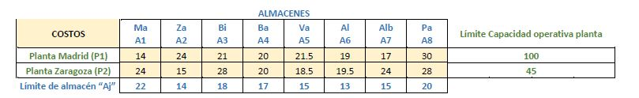

#### Modelización Matemática:

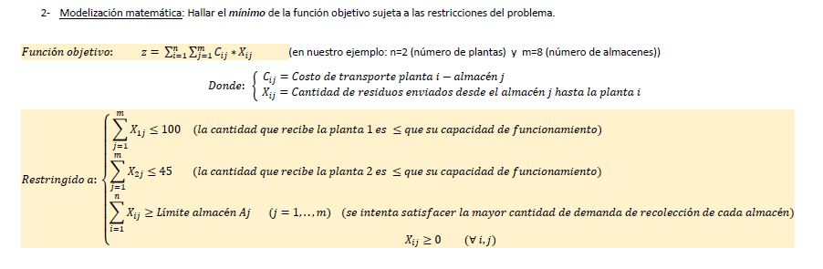

En este problema se interpreta a las plantas de tratamiento como proveedoras de servicios y a los almacenes como demanda (o clientes) del servicio de tratamiento.

#### Código:

La salida mostrará el `valor de la función objetivo` y en `$solution` se mostrará una matriz que reflejará cuántas toneladas RAEE se trasladarán desde el almacén columna `"j"` hasta la planta fila `"i"`

```r
library(lpSolve)
# especificamos la matriz de costos
cost.mat <- matrix(nrow=2,ncol=8)
cost.mat[1,] <- c(14,24,21,20,21.5,19,17,30)
cost.mat[2,] <- c(24,15,28,20,18.5,19.5,24,28)

# no se puede exceder la capacidad de las plantas
row.signs <- rep("<=",2)
row.rhs <- c(100,45)

# la demanda de los almacenes debe ser satisfecha
col.signs <- rep(">=",8)
col.rhs <- c(22,14,18,17,15,13,15,20)

# problema de minimización
direction = "min"

distribucion <- lp.transport(cost.mat,direction,
                         row.signs,row.rhs,
                         col.signs, col.rhs)

#ver el costo mínimo total alcanzado:
distribucion
```

```
## Success: the objective function is 2583.5
```

```r
#ver distribución matricial planta-almacén (proveedor-cliente):
distribucion$solution
```

```
##      [,1] [,2] [,3] [,4] [,5] [,6] [,7] [,8]
## [1,]   22    0   18   17    0   13   15    4
## [2,]    0   14    0    0   15    0    0   16
```

Aquí otro, [Ejemplo sencillo](https://www.supplychaindataanalytics.com/es/resolviendo-el-problema-de-transporte-lineal-con-lp-transport-en-r-usando-lpsolve/)

## Para conocer más:

- Visita las fuentes linkeadas en este escrito.
- https://cran.r-project.org/web/packages/linprog/
- Investiga programación lineal con R. (Por ejemplo en rpubs: https://rpubs.com/Jaime90/335146 )
- Anímate a [LaTeX](https://manualdelatex.com/simbolos)